# Machine Learning Assignment

Enrique Repullés

# Introduction

The purpose of this study is to predict the execution way of a gym activity as performed by several participants.

The experiment consists of 10 repetitions of an “Unilateral Dumbbell Biceps Curl”, and the outcome that is being clasified is how well the exercice was executed, according with the following categories:

- Class A: exactly according to the specification.
- Class B: throwing the elbows to the front.
- Class C: lifting the dumbbell only halfway.
- Class D: lowering the dumbbell only halfway.
- Class E: and throwing the hips to the front.

The variables used for the prediction come from several sensors that detect movements like skewness_pitch_arm, avg_roll_dumbbell, amplitude_yaw_forearm, etc

The data is downloaded from the study in this site: http://groupware.les.inf.puc-rio.br/har

# Data analysis and cleaning

```r
file.training = "pml-training.csv"
file.testing = "pml-testing.csv"

nastrings = c("NA","","#DIV/0!")
total.training <- read.csv(file.training, na.strings = nastrings)
testing <- read.csv(file.testing)
```

First of all, we split the data set into training and validation

```r
set.seed(1111)
inTrain <- createDataPartition(y=total.training$classe, p=.75, list=FALSE)
training <- total.training[inTrain,]
validation <- total.training[-inTrain,]
```

After performing some exploratory data analysis, the following points stand out:

- There are several different codes identifying incomplete data: NA, empty string (“”) and “#DIV/0!”. We treat all these codes as NA.
- Some variables have a lot of nulls (>90%):

```r
hightNullRatio <- sapply(names(training),nullRate) > .9
table(hightNullRatio)
```

```
## hightNullRatio
## FALSE  TRUE
##    60   100
```

- Some variables have very low variance:

```r
nz <- nearZeroVar(training, saveMetrics = TRUE)
table(nz$nzv)
```

```
##
## FALSE  TRUE
##   124    36
```

- The first variable in the data file is the row number. We must discard this variable because it is not part of the experiment and is very correlated with the outcome, so the training algortihm can be misleaded by this variable. In the following plot we show the spurious correlation between row number and the class.

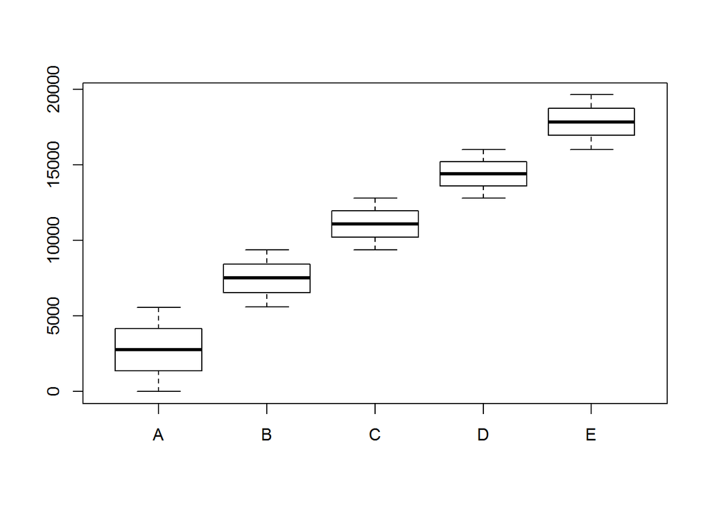

```r
plot(training$classe, training$X)
```

# Training

We discard the variables with a high level of noise: high ratio of NA, near zero variance, and the first variable (the row number)

```r
discarded <- nz$nzv | hightNullRatio | names(training) == "classe" | names(training) == "X"
```

The selected set of variables are:

```r
features <- names(training)[!discarded]
form <- paste("classe", paste(features, collapse=" + "), sep=" ~ ")
print(form)
```

[output not shown]

For the prediction, the method selected is the random forests algorithm, because:

- it includes cross validation and variable selection with bootstrap
- the outcome variable is categorical with several possible categories, thus a tree structure is more suitable than a regression.

```r
modelFit <- train(formula(form)  , method="rf", data=training)
```

The trained model has the following parameters:

```
##
## Call:
##  randomForest(x = x, y = y, mtry = param$mtry)
##                Type of random forest: classification
##                      Number of trees: 500
## No. of variables tried at each split: 40
##
##         OOB estimate of  error rate: 0.07%
## Confusion matrix:
##      A    B    C    D    E  class.error
## A 4185    0    0    0    0 0.0000000000
## B    2 2845    1    0    0 0.0010533708
## C    0    3 2563    1    0 0.0015582392
## D    0    0    1 2410    1 0.0008291874
## E    0    0    0    1 2705 0.0003695492
```

# Out of sample error

[output not shown]

Finally, we use the validation data set to estimate the out-of-sample error:

```r
confusionMatrix(validation$classe,predict(modelFit, validation))
```

```
## Confusion Matrix and Statistics
##
##           Reference
## Prediction    A    B    C    D    E
##          A 1395    0    0    0    0
##          B    0  949    0    0    0
##          C    0    1  854    0    0
##          D    0    0    0  804    0
##          E    0    0    0    0  901
##
## Overall Statistics
##
##                Accuracy : 0.9998
##                  95% CI : (0.9989, 1)
##     No Information Rate : 0.2845
##     P-Value [Acc > NIR] : < 2.2e-16
##
##                   Kappa : 0.9997
##  Mcnemar's Test P-Value : NA
##
## Statistics by Class:
##
##                      Class: A Class: B Class: C Class: D Class: E
## Sensitivity            1.0000   0.9989   1.0000   1.0000   1.0000
## Specificity            1.0000   1.0000   0.9998   1.0000   1.0000
## Pos Pred Value         1.0000   1.0000   0.9988   1.0000   1.0000
## Neg Pred Value         1.0000   0.9997   1.0000   1.0000   1.0000
## Prevalence             0.2845   0.1937   0.1741   0.1639   0.1837
## Detection Rate         0.2845   0.1935   0.1741   0.1639   0.1837
## Detection Prevalence   0.2845   0.1935   0.1743   0.1639   0.1837
## Balanced Accuracy      1.0000   0.9995   0.9999   1.0000   1.0000
```